# Luu_Computational6

Hon Luu

6/2/2020

```r
library(ggplot2)
library(psych)
library(dplyr)
data <- read.csv('stress.csv')
```

##### 1. For the STRESS variable, make a histogram and obtain summary statistics. Obtain a normal probability (Q-Q) plot for the STRESS variable. Is STRESS a normally distributed variable? What do you think is its most likely probability distribution for STRESS? Give a justification for the distribution you selected.

Based on the histogram and the QQ plot, it does not appear that Stress is normally distributed. Based on the skewness of the bar chart, it does appear to resemble a poisson or a negative binomial distribution. Inspecting the mean and variance, they are not equal. In fact, the variance is almost twice as high as the mean, so it’s overdispersed negative binomial distribution.

```r
describe(data$STRESS)
```

```
##    vars   n mean   sd median trimmed  mad min max range skew kurtosis   se
## X1    1 651 1.73 1.85      1    1.44 1.48   0   9     9 1.27     1.61 0.07
```

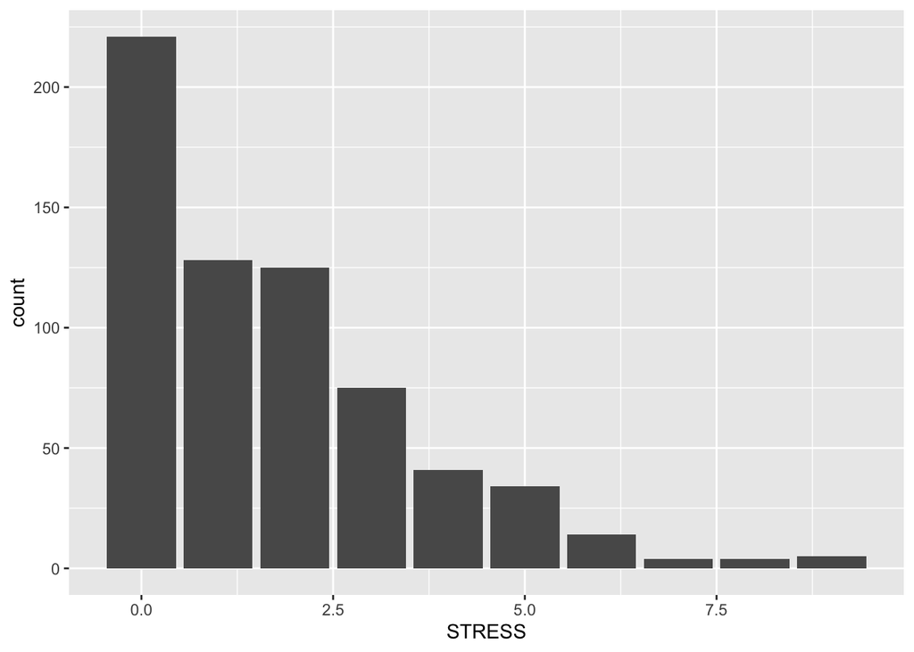

```r
ggplot(data=data, aes(x=STRESS)) + geom_bar()
```

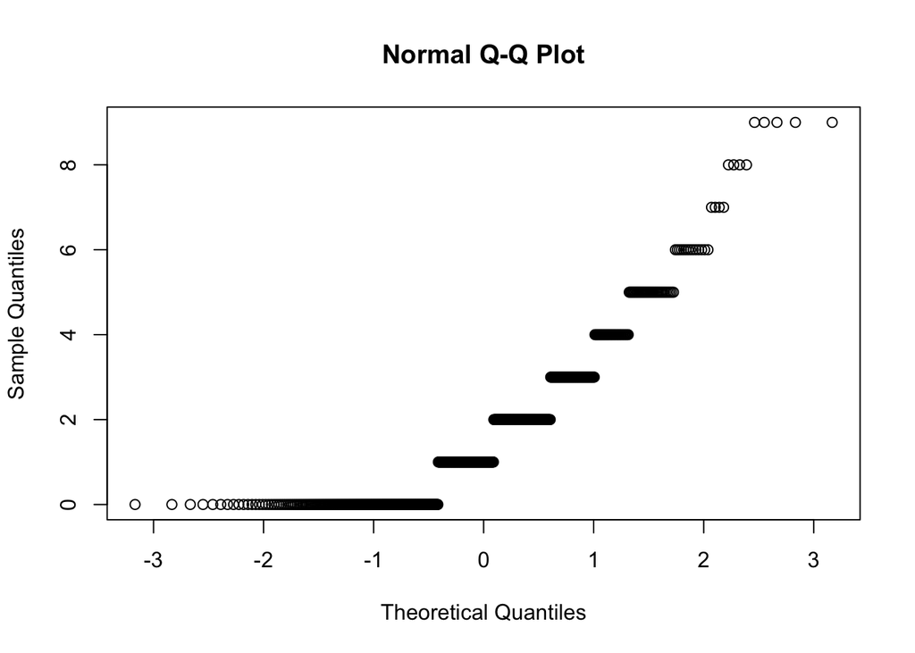

```r
qqnorm(data$STRESS)
```

```r
library(MASS)
library(pscl)
```

##### 2. Fit an OLS regression model to predict STRESS (Y) using COHES, ESTEEM, GRADES, SATTACH as explanatory variables (X). Obtain the typical diagnostic information and graphs. Discuss how well this model fits. Obtain predicted values (Y_hat) and plot them in a histogram. What issues do you see?

The equation for this model is $Stress = 5.71281 -.02319*Cohes - .04129*Esteem -.04170*Grades - .03042*Sattach$.  
The adjusted $R^2$ is .078, so this model explains only the 7.8% of the variance.  
The diagnostics do not fit too well based on the plots (because the datat is not noramlly distributed:  
Residual vs fitted doesn’t look random, the QQ plot appears to fail the pen test.  
Another major concern is that with a linear regression, its very possible to get negative values, so a OLS model may not be the best.

```r
model1 <- lm(STRESS~COHES+ESTEEM+GRADES+SATTACH, data=data)
summary(model1)
```

```
##
## Call:
## lm(formula = STRESS ~ COHES + ESTEEM + GRADES + SATTACH, data = data)
##
## Residuals:
##     Min      1Q  Median      3Q     Max
## -3.1447 -1.3827 -0.3819  0.9504  6.9525
##
## Coefficients:
##             Estimate Std. Error t value Pr(>|t|)
## (Intercept)  5.71281    0.58118   9.830  < 2e-16 ***
## COHES       -0.02319    0.00703  -3.298  0.00103 **
## ESTEEM      -0.04129    0.01933  -2.136  0.03305 *
## GRADES      -0.04170    0.02352  -1.773  0.07670 .
## SATTACH     -0.03042    0.01412  -2.154  0.03160 *
## ---
## Signif. codes:  0 '***' 0.001 '**' 0.01 '*' 0.05 '.' 0.1 ' ' 1
##
## Residual standard error: 1.776 on 646 degrees of freedom
## Multiple R-squared:  0.08319,    Adjusted R-squared:  0.07751
## F-statistic: 14.65 on 4 and 646 DF,  p-value: 1.826e-11
```

```r
anova((model1))
```

```
## Analysis of Variance Table
##
## Response: STRESS
##            Df  Sum Sq Mean Sq F value    Pr(>F)
## COHES       1  122.93 122.930 38.9749 7.777e-10 ***
## ESTEEM      1   31.26  31.264  9.9122  0.001718 **
## GRADES      1   16.05  16.052  5.0894  0.024407 *
## SATTACH     1   14.64  14.635  4.6401  0.031602 *
## Residuals 646 2037.54   3.154
## ---
## Signif. codes:  0 '***' 0.001 '**' 0.01 '*' 0.05 '.' 0.1 ' ' 1
```

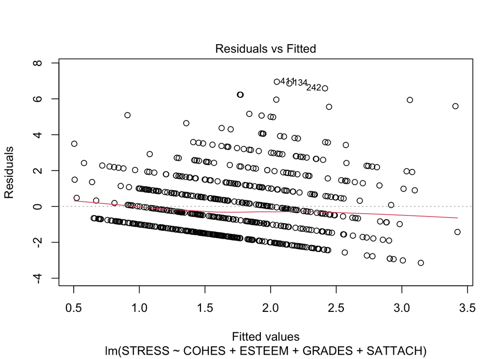

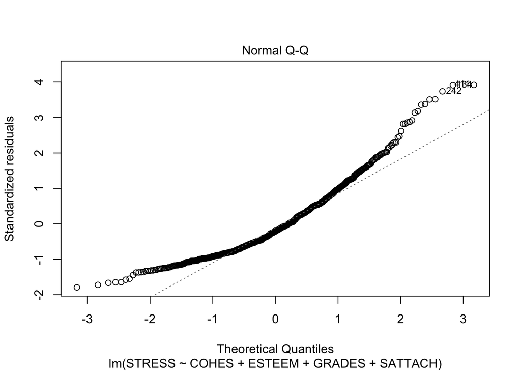

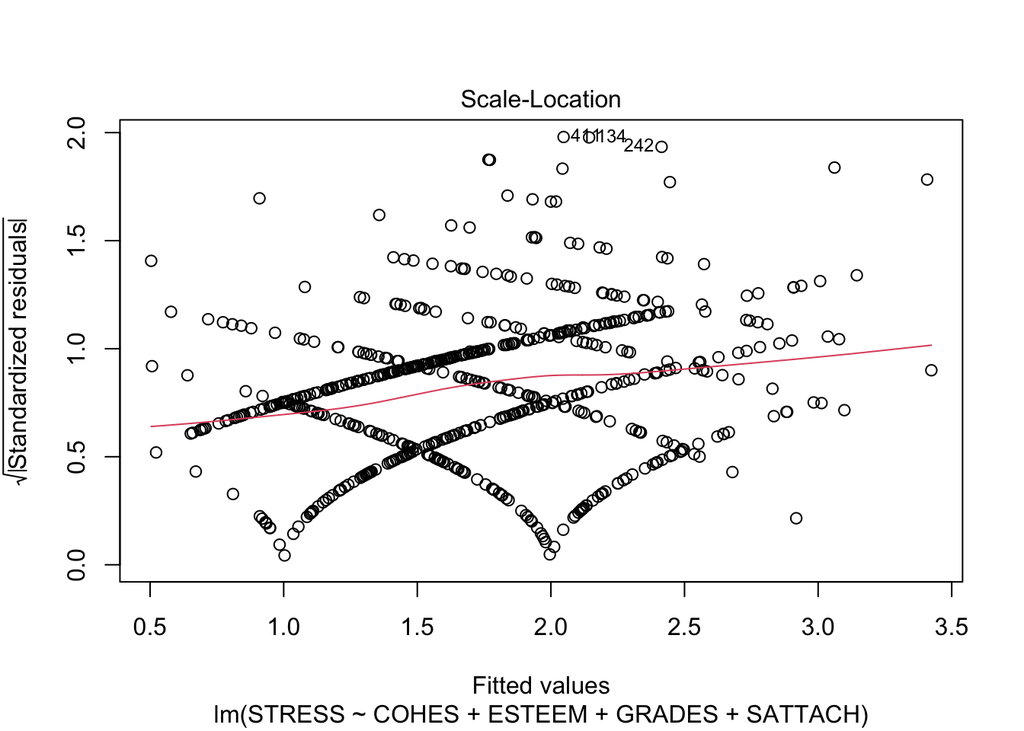

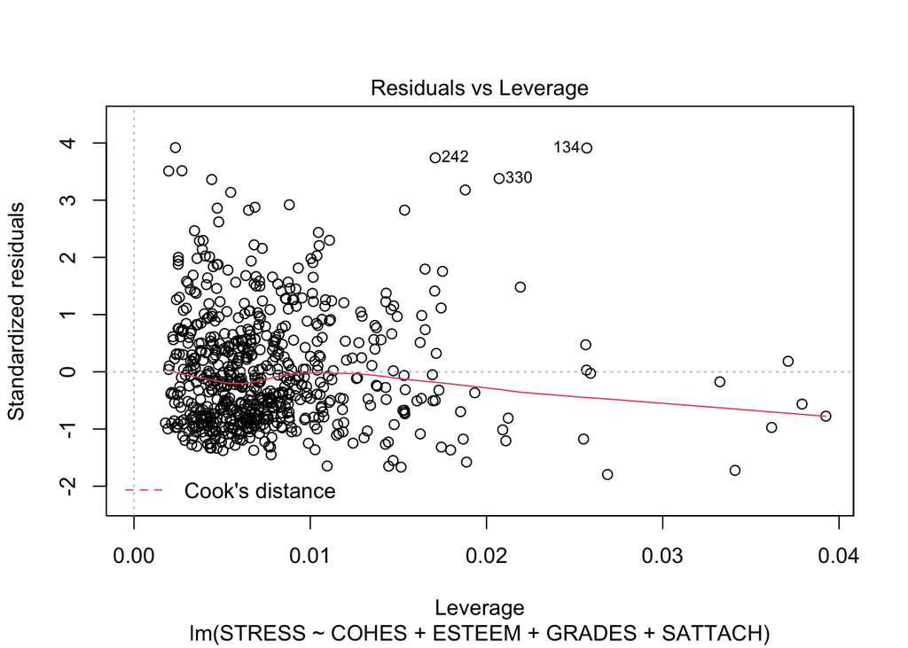

```r
plot(model1)
```

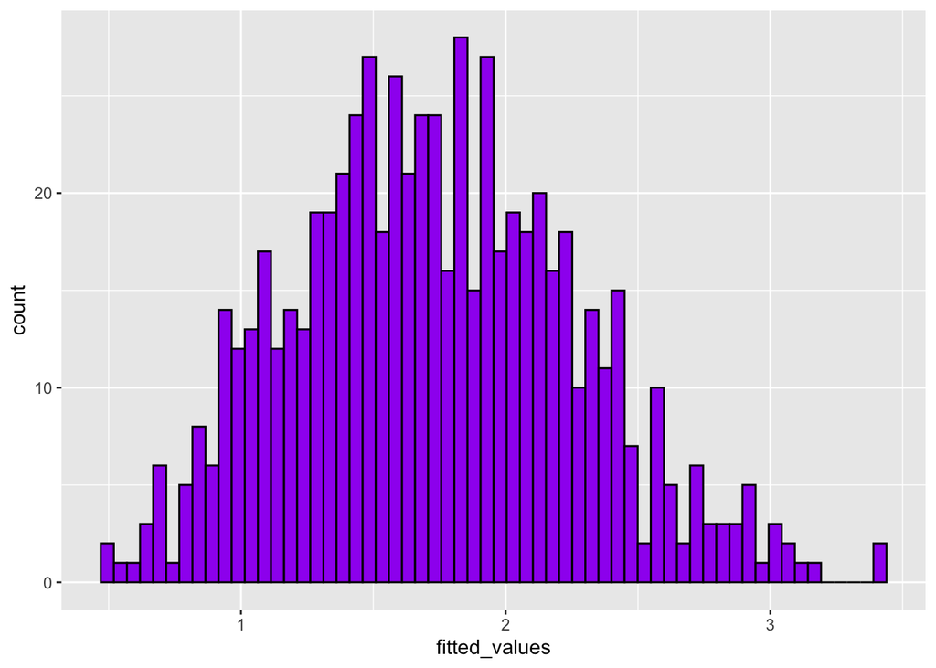

```r
Y_hats<-data.frame(fitted_values=model1$fitted.values)
ggplot(data=Y_hats, aes(x=fitted_values)) + geom_histogram(bins=60, color="black", fill = "purple")
```

##### 3. Create a transformed variable on Y that is LN(Y). Fit an OLS regression model to predict LN(Y) using COHES, ESTEEM, GRADES, SATTACH as explanatory variables (X). Obtain the typical diagnostic information and graphs. Discuss how well this model fits. Obtain predicted values (LN(Y)_hat) and plot them in a histogram. What issues do you see? Does this correct the issue? *** The first issue is that $log(0)$ is undefined, so the model errors out. As there are majority observations with zeros removing them may be changing the story of the analysis. Removing the 0s does output a model, but we see the same situation with model diagnstics. More importantly, we lost about 33% of our data.

```r
data$logStress <- log(data$STRESS)
data2<-data
data2$STRESS<- ifelse(data$STRESS==0,NA,data$STRESS)
data2$logStress <- log(data$STRESS)
data2 <- data2 %>% filter(STRESS >0)
model2 <- lm(logStress~COHES+ESTEEM+GRADES+SATTACH, data=data2)
summary(model2)
```

```
##
## Call:
## lm(formula = logStress ~ COHES + ESTEEM + GRADES + SATTACH, data = data2)
##
## Residuals:
##     Min      1Q  Median      3Q     Max
## -1.1201 -0.5951  0.0204  0.4655  1.3813
##
## Coefficients:
##              Estimate Std. Error t value Pr(>|t|)
## (Intercept)  1.960830   0.239249   8.196 2.96e-15 ***
## COHES       -0.005233   0.002881  -1.816   0.0700 .
## ESTEEM      -0.013694   0.007946  -1.723   0.0855 .
## GRADES      -0.016140   0.009422  -1.713   0.0874 .
## SATTACH     -0.009408   0.005753  -1.635   0.1027
## ---
## Signif. codes:  0 '***' 0.001 '**' 0.01 '*' 0.05 '.' 0.1 ' ' 1
##
## Residual standard error: 0.5955 on 425 degrees of freedom
## Multiple R-squared:  0.0663, Adjusted R-squared:  0.05752
## F-statistic: 7.545 on 4 and 425 DF,  p-value: 7.036e-06
```

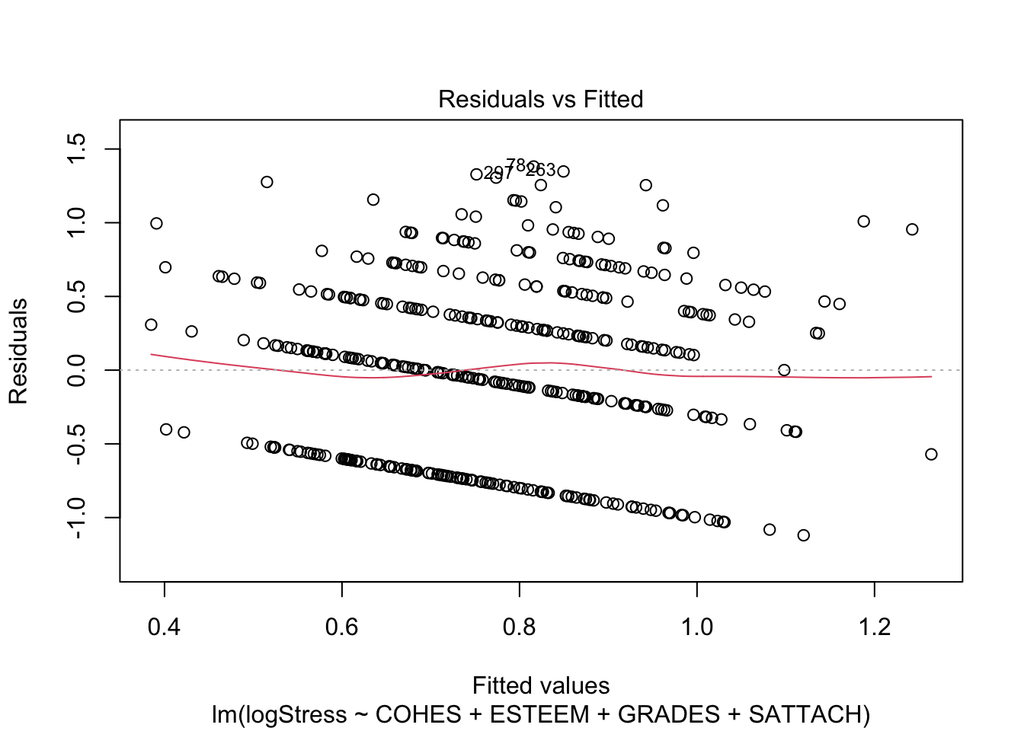

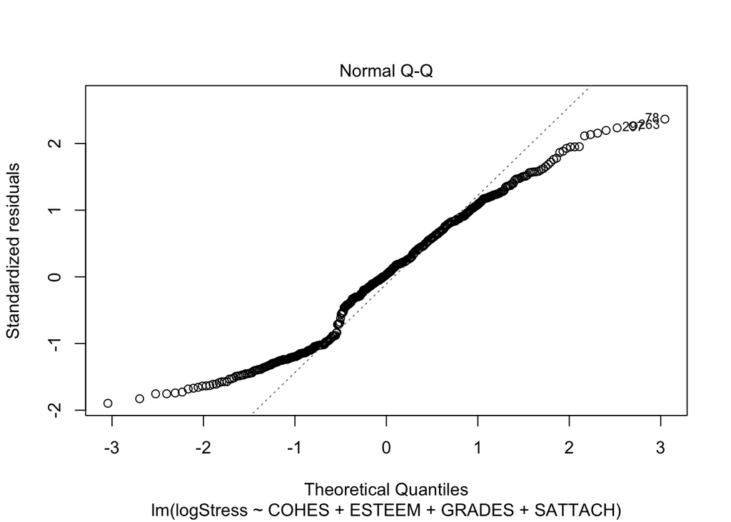

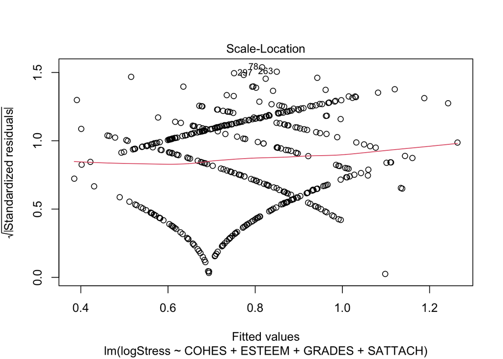

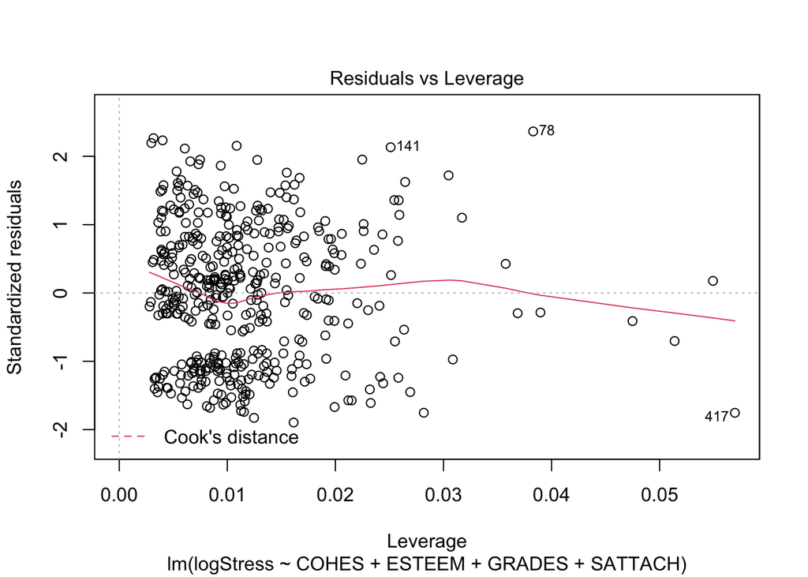

```r
plot(model2)
```

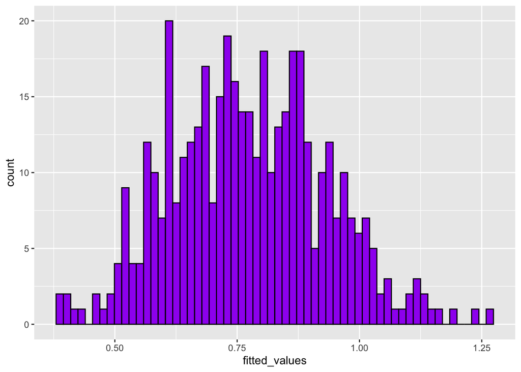

```r
Y_hats<-data.frame(fitted_values=model2$fitted.values)
ggplot(data=Y_hats, aes(x=fitted_values)) + geom_histogram(bins=60, color="black", fill = "purple")
```

##### 4. Use the glm() function to fit a Poisson Regression for STRESS (Y) using COHES, ESTEEM, GRADES, SATTACH as explanatory variables (X). Interpret the model’s coefficients and discuss how this model’s results compare to your answer for part 3). Similarly, fit an over-dispersed Poisson regression model using the same set of variables. How do these models compare?

```r
poisson1 <- glm(STRESS~COHES+ESTEEM+GRADES+SATTACH, data=data, family = "poisson")
summary(poisson1)
```

```
##
## Call:
## glm(formula = STRESS ~ COHES + ESTEEM + GRADES + SATTACH, family = "poisson",
##     data = data)
##
## Deviance Residuals:
##     Min       1Q   Median       3Q      Max
## -2.7111  -1.5989  -0.2914   0.7107   3.6424
##
## Coefficients:
##              Estimate Std. Error z value Pr(>|z|)
## (Intercept)  2.734513   0.234066  11.683  < 2e-16 ***
## COHES       -0.012918   0.002893  -4.466 7.98e-06 ***
## ESTEEM      -0.023692   0.008039  -2.947  0.00321 **
## GRADES      -0.023471   0.009865  -2.379  0.01735 *
## SATTACH     -0.016481   0.005783  -2.850  0.00437 **
## ---
## Signif. codes:  0 '***' 0.001 '**' 0.01 '*' 0.05 '.' 0.1 ' ' 1
##
## (Dispersion parameter for poisson family taken to be 1)
##
##     Null deviance: 1349.8  on 650  degrees of freedom
## Residual deviance: 1245.4  on 646  degrees of freedom
## AIC: 2417.2
##
## Number of Fisher Scoring iterations: 5
```

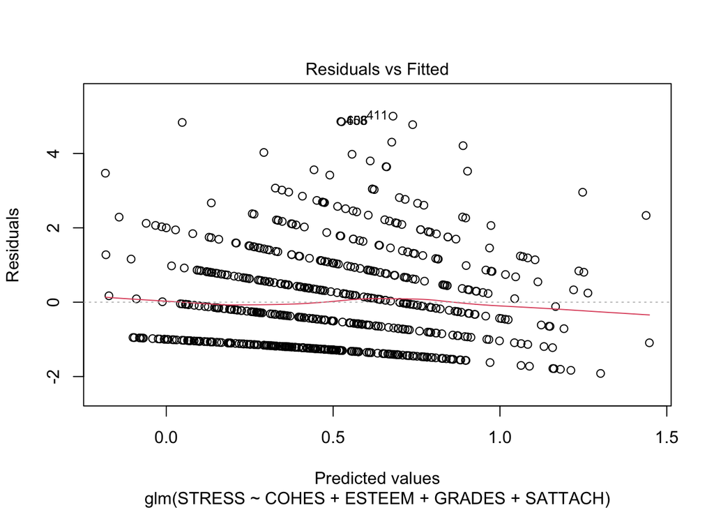

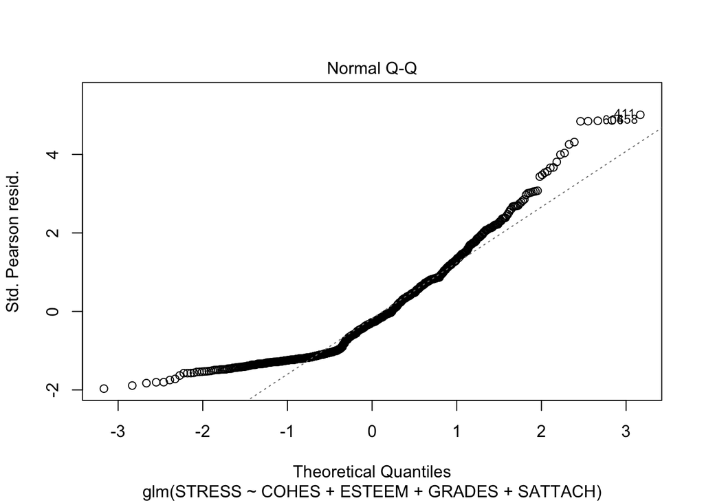

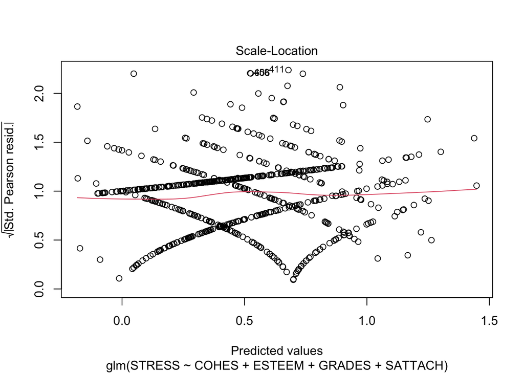

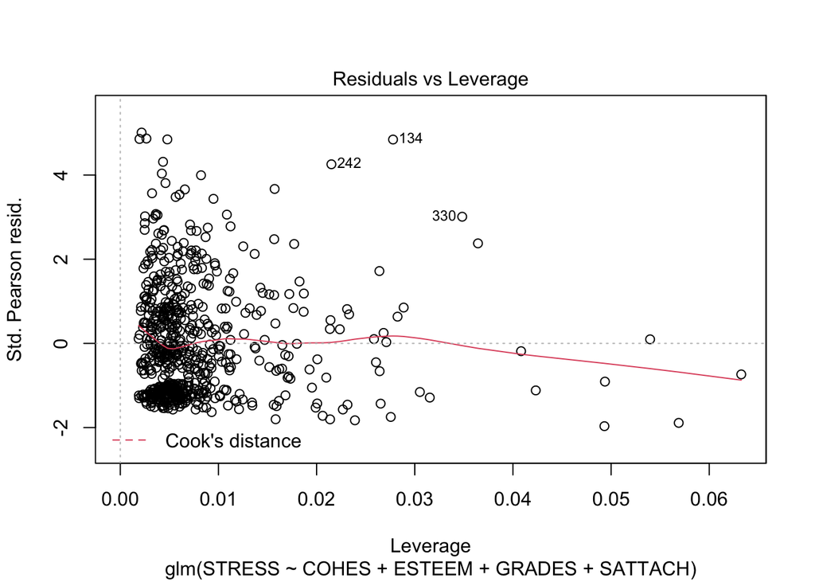

```r
plot(poisson1)
```

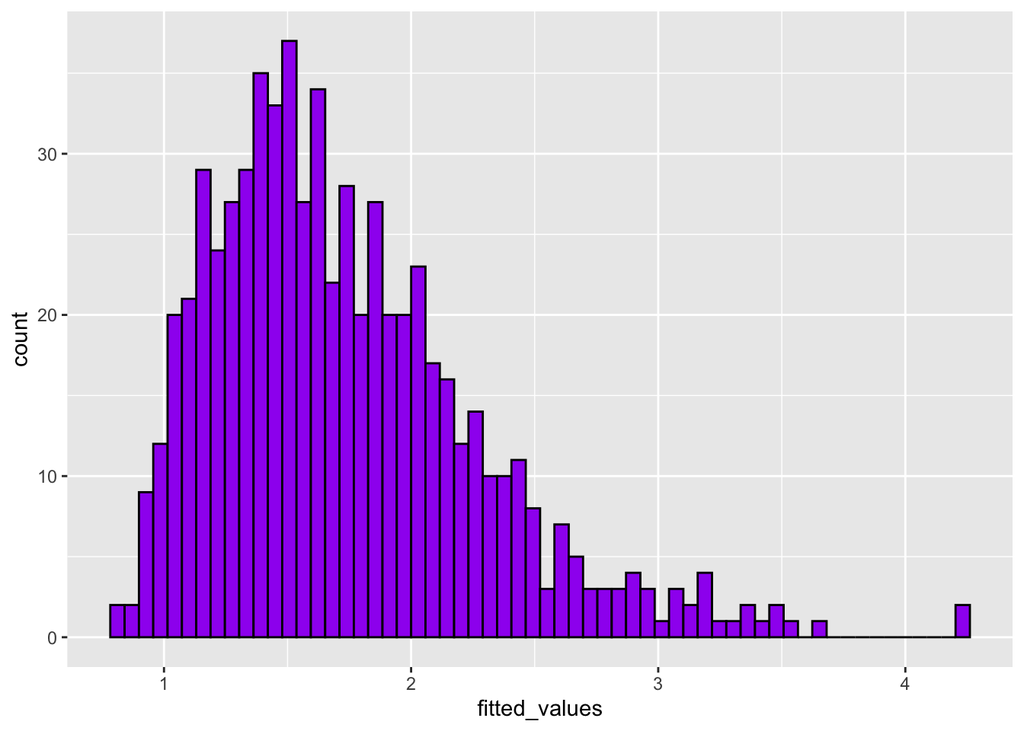

```r
Y_hats<-data.frame(fitted_values=poisson1$fitted.values)
ggplot(data=Y_hats, aes(x=fitted_values)) + geom_histogram(bins=60, color="black", fill = "purple")
```

```r
poisson2 <- glm(STRESS~COHES+ESTEEM+GRADES+SATTACH, data=data, family = "quasipoisson")
summary(poisson2)
```

```
##
## Call:
## glm(formula = STRESS ~ COHES + ESTEEM + GRADES + SATTACH, family = "quasipoisson",
##     data = data)
##
## Deviance Residuals:
##     Min       1Q   Median       3Q      Max
## -2.7111  -1.5989  -0.2914   0.7107   3.6424
##
## Coefficients:
##              Estimate Std. Error t value Pr(>|t|)
## (Intercept)  2.734513   0.312160   8.760  < 2e-16 ***
## COHES       -0.012918   0.003858  -3.348  0.00086 ***
## ESTEEM      -0.023692   0.010721  -2.210  0.02746 *
## GRADES      -0.023471   0.013157  -1.784  0.07490 .
## SATTACH     -0.016481   0.007712  -2.137  0.03297 *
## ---
## Signif. codes:  0 '***' 0.001 '**' 0.01 '*' 0.05 '.' 0.1 ' ' 1
##
## (Dispersion parameter for quasipoisson family taken to be 1.778603)
##
##     Null deviance: 1349.8  on 650  degrees of freedom
## Residual deviance: 1245.4  on 646  degrees of freedom
## AIC: NA
##
## Number of Fisher Scoring iterations: 5
```

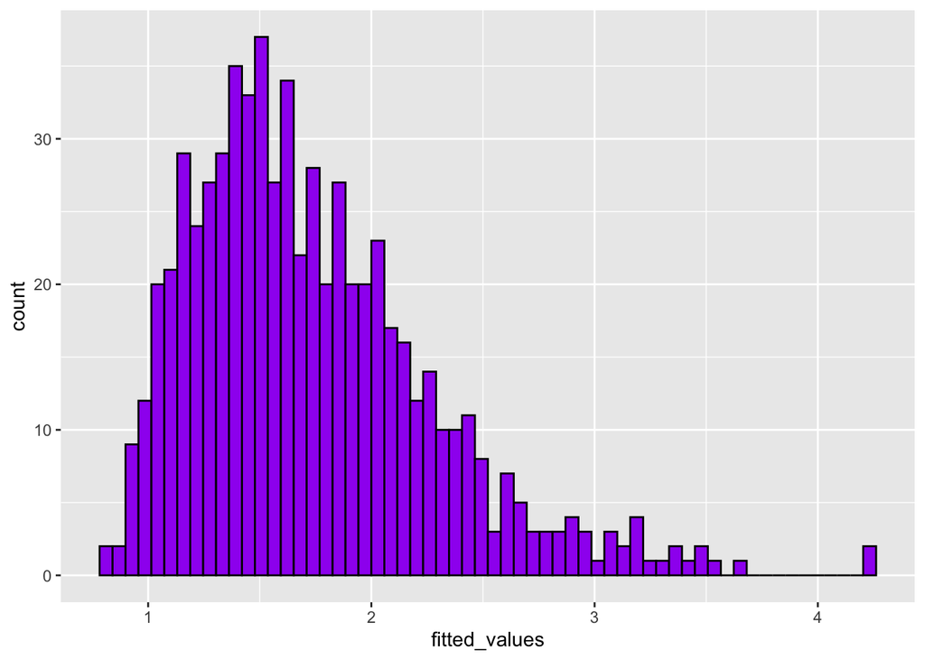

```r
Y_hats2<-data.frame(fitted_values=poisson2$fitted.values)
ggplot(data=Y_hats2, aes(x=fitted_values)) + geom_histogram(bins=60, color="black", fill = "purple")
```

##### 5. Based on the Poisson model in part 4), compute the predicted count of STRESS for those whose levels of family cohesion are less than one standard deviation below the mean (call this the low group), between one standard deviation below and one standard deviation above the mean (call this the middle group), and more than one standard deviation above the mean (high). What is the expected percent difference in the number of stressful events for those at high and low levels of family cohesion?

The mean count for “low”, “middle”, “high” is 2.502, 1.66,1.189. The differences between

low-medium: 50.2% low-high: 110% medium-high: 40%

```r
describe(data$COHES)
```

```
##    vars   n mean    sd median trimmed   mad min max range  skew kurtosis   se
## X1    1 651   53 11.38     54   53.58 11.86  18  75    57 -0.43    -0.29 0.45
```

```r
data$COHESGroup <- ifelse(data$COHES <=41.62,"low",ifelse(data$COHES<=64.38,"middle","high"))
data$fitted <- poisson1$fitted.values

tapply(data$fitted, list(data$COHESGroup), mean)
```

```
##     high      low   middle
## 1.188274 2.502785 1.666067
```

##### 6. Compute the AICs and BICs from the Poisson Regression and the over-dispersed Poisson regression models from part 4). Is one better than the other?

```r
nb<-glm.nb(STRESS~COHES+ESTEEM+GRADES+SATTACH, data=data)

summary(nb)
```

```
##
## Call:
## glm.nb(formula = STRESS ~ COHES + ESTEEM + GRADES + SATTACH,
##     data = data, init.theta = 1.865329467, link = log)
##
## Deviance Residuals:
##     Min       1Q   Median       3Q      Max
## -2.0179  -1.3900  -0.2214   0.4882   2.3199
##
## Coefficients:
##              Estimate Std. Error z value Pr(>|z|)
## (Intercept)  2.759032   0.341531   8.078 6.56e-16 ***
## COHES       -0.013391   0.004136  -3.238  0.00121 **
## ESTEEM      -0.023058   0.011477  -2.009  0.04453 *
## GRADES      -0.024360   0.013969  -1.744  0.08118 .
## SATTACH     -0.016750   0.008296  -2.019  0.04349 *
## ---
## Signif. codes:  0 '***' 0.001 '**' 0.01 '*' 0.05 '.' 0.1 ' ' 1
##
## (Dispersion parameter for Negative Binomial(1.8653) family taken to be 1)
##
##     Null deviance: 792.47  on 650  degrees of freedom
## Residual deviance: 738.53  on 646  degrees of freedom
## AIC: 2283.6
##
## Number of Fisher Scoring iterations: 1
##
##
##               Theta:  1.865
##           Std. Err.:  0.257
##
##  2 x log-likelihood:  -2271.590
```

```r
poissonAIC<-AIC(poisson1)
poissonBIC <-BIC(poisson1)
nbAIC<-AIC(nb)
nbBIC<-BIC(nb)
```

The quasi poisson did not generate an AIC, so I re-ran the model using a negative binomal. The AIC and BIC for the poisson is 2417.2190347 and 2439.6115829 respectively. The AIC for the negative binomial is 2283.5899597 and 2310.4610176 respectively. the lower AIC/BIC on the negative binomial appears to suggest that the negative binomial is a better model

##### 7. Using the Poisson regression model from part 4), plot the deviance residuals by the predicted values. Discuss what this plot indicates about the regression model.

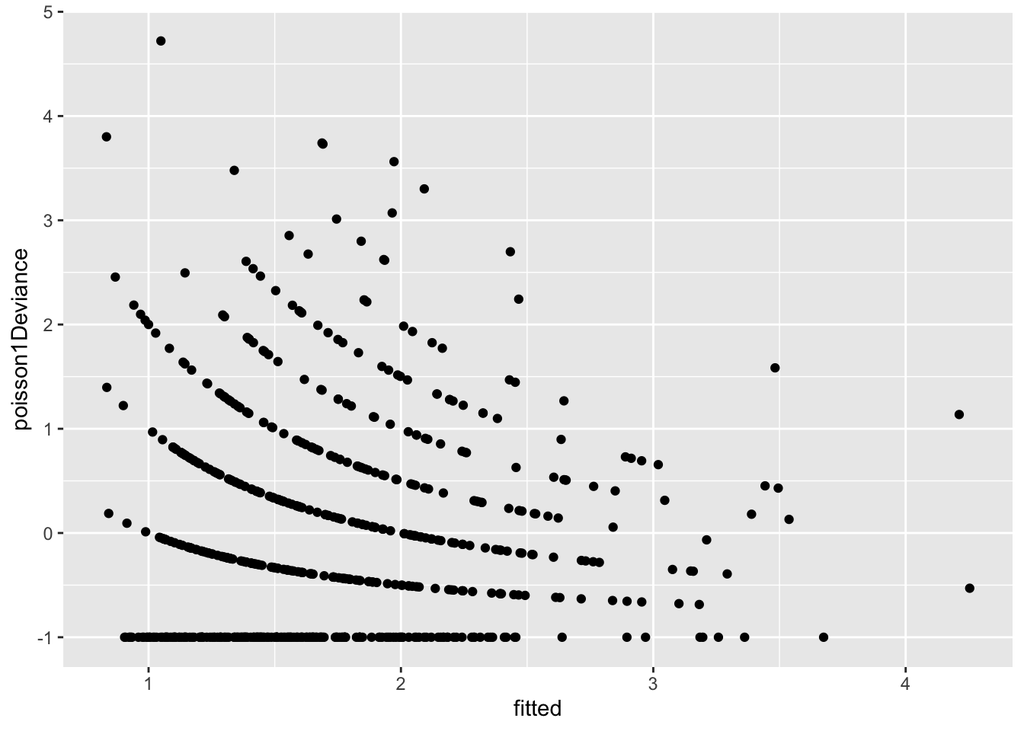

```r
data$poisson1Deviance<-poisson1$residuals

ggplot(data=data, aes(x=fitted, y = poisson1Deviance)) + geom_jitter(fill = "purple")
```

##### 8. Create a new indicator variable (Y_IND) of STRESS that takes on a value of 0 if STRESS=0 and 1 if STRESS>0. This variable essentially measures is stress present, yes or no. Fit a logistic regression model to predict Y_IND using the variables using COHES, ESTEEM, GRADES, SATTACH as explanatory variables (X). Report the model, interpret the coefficients, obtain statistical information on goodness of fit, and discuss how well this model fits. Should you rerun the logistic regression analysis? If so, what should you do next?

```r
data$Y_IND <- ifelse(data$STRESS==0,0,1)
#data$Y_IND <- as.factor(data$Y_IND)

logit1 <- glm(Y_IND~ COHES+ESTEEM+GRADES+SATTACH, data=data)
summary(logit1)
```

```
##
## Call:
## glm(formula = Y_IND ~ COHES + ESTEEM + GRADES + SATTACH, data = data)
##
## Deviance Residuals:
##     Min       1Q   Median       3Q      Max
## -0.8645  -0.5869   0.2685   0.3602   0.5328
##
## Coefficients:
##              Estimate Std. Error t value Pr(>|t|)
## (Intercept)  1.264559   0.152938   8.268 7.74e-16 ***
## COHES       -0.004406   0.001850  -2.382   0.0175 *
## ESTEEM      -0.004159   0.005087  -0.818   0.4139
## GRADES      -0.005465   0.006189  -0.883   0.3776
## SATTACH     -0.005831   0.003717  -1.569   0.1172
## ---
## Signif. codes:  0 '***' 0.001 '**' 0.01 '*' 0.05 '.' 0.1 ' ' 1
##
## (Dispersion parameter for gaussian family taken to be 0.2184146)
##
##     Null deviance: 145.98  on 650  degrees of freedom
## Residual deviance: 141.10  on 646  degrees of freedom
## AIC: 864.03
##
## Number of Fisher Scoring iterations: 2
```

```r
logit2 <- glm(Y_IND~ESTEEM+GRADES+SATTACH, data=data)
logit3 <- glm(Y_IND~ COHES+GRADES+SATTACH, data=data)
logit4 <- glm(Y_IND~ COHES+ESTEEM+SATTACH, data=data)
logit5 <- glm(Y_IND~ COHES+ESTEEM+GRADES, data=data)

anova(logit1,logit2)
```

```
## Analysis of Deviance Table
##
## Model 1: Y_IND ~ COHES + ESTEEM + GRADES + SATTACH
## Model 2: Y_IND ~ ESTEEM + GRADES + SATTACH
##   Resid. Df Resid. Dev Df Deviance
## 1       646     141.10
## 2       647     142.34 -1   -1.239
```

```r
anova(logit1,logit3)
```

```
## Analysis of Deviance Table
##
## Model 1: Y_IND ~ COHES + ESTEEM + GRADES + SATTACH
## Model 2: Y_IND ~ COHES + GRADES + SATTACH
##   Resid. Df Resid. Dev Df Deviance
## 1       646     141.10
## 2       647     141.24 -1 -0.14601
```

```r
anova(logit1,logit4)
```

```
## Analysis of Deviance Table
##
## Model 1: Y_IND ~ COHES + ESTEEM + GRADES + SATTACH
## Model 2: Y_IND ~ COHES + ESTEEM + SATTACH
##   Resid. Df Resid. Dev Df Deviance
## 1       646     141.10
## 2       647     141.27 -1 -0.17028
```

```r
anova(logit1,logit5)
```

```
## Analysis of Deviance Table
##
## Model 1: Y_IND ~ COHES + ESTEEM + GRADES + SATTACH
## Model 2: Y_IND ~ COHES + ESTEEM + GRADES
##   Resid. Df Resid. Dev Df Deviance
## 1       646     141.10
## 2       647     141.63 -1 -0.53762
```

```r
summary(logit2)
```

```
##
## Call:
## glm(formula = Y_IND ~ ESTEEM + GRADES + SATTACH, data = data)
##
## Deviance Residuals:
##     Min       1Q   Median       3Q      Max
## -0.9333  -0.5955   0.2807   0.3592   0.5124
##
## Coefficients:
##              Estimate Std. Error t value Pr(>|t|)
## (Intercept)  1.230998   0.152836   8.054 3.85e-15 ***
## ESTEEM      -0.007985   0.004844  -1.648   0.0998 .
## GRADES      -0.007389   0.006159  -1.200   0.2307
## SATTACH     -0.007673   0.003649  -2.103   0.0359 *
## ---
## Signif. codes:  0 '***' 0.001 '**' 0.01 '*' 0.05 '.' 0.1 ' ' 1
##
## (Dispersion parameter for gaussian family taken to be 0.219992)
##
##     Null deviance: 145.98  on 650  degrees of freedom
## Residual deviance: 142.33  on 647  degrees of freedom
## AIC: 867.72
##
## Number of Fisher Scoring iterations: 2
```

```r
summary(logit3)
```

```
##
## Call:
## glm(formula = Y_IND ~ COHES + GRADES + SATTACH, data = data)
##
## Deviance Residuals:
##     Min       1Q   Median       3Q      Max
## -0.8506  -0.5899   0.2693   0.3605   0.5215
##
## Coefficients:
##              Estimate Std. Error t value Pr(>|t|)
## (Intercept)  1.185364   0.118325  10.018  < 2e-16 ***
## COHES       -0.004884   0.001755  -2.783  0.00554 **
## GRADES      -0.006198   0.006123  -1.012  0.31175
## SATTACH     -0.006468   0.003633  -1.780  0.07551 .
## ---
## Signif. codes:  0 '***' 0.001 '**' 0.01 '*' 0.05 '.' 0.1 ' ' 1
##
## (Dispersion parameter for gaussian family taken to be 0.2183027)
##
##     Null deviance: 145.98  on 650  degrees of freedom
## Residual deviance: 141.24  on 647  degrees of freedom
## AIC: 862.71
##
## Number of Fisher Scoring iterations: 2
```

```r
summary(logit4)
```

```
##
## Call:
## glm(formula = Y_IND ~ COHES + ESTEEM + SATTACH, data = data)
##
## Deviance Residuals:
##     Min       1Q   Median       3Q      Max
## -0.8653  -0.5837   0.2722   0.3595   0.5307
##
## Coefficients:
##              Estimate Std. Error t value Pr(>|t|)
## (Intercept)  1.232800   0.148623   8.295 6.32e-16 ***
## COHES       -0.004619   0.001834  -2.519   0.0120 *
## ESTEEM      -0.004810   0.005033  -0.956   0.3395
## SATTACH     -0.006496   0.003639  -1.785   0.0747 .
## ---
## Signif. codes:  0 '***' 0.001 '**' 0.01 '*' 0.05 '.' 0.1 ' ' 1
##
## (Dispersion parameter for gaussian family taken to be 0.2183402)
##
##     Null deviance: 145.98  on 650  degrees of freedom
## Residual deviance: 141.27  on 647  degrees of freedom
## AIC: 862.82
##
## Number of Fisher Scoring iterations: 2
```

```r
summary(logit5)
```

```
##
## Call:
## glm(formula = Y_IND ~ COHES + ESTEEM + GRADES, data = data)
##
## Deviance Residuals:
##     Min       1Q   Median       3Q      Max
## -0.9013  -0.5843   0.2701   0.3605   0.5199
##
## Coefficients:
##              Estimate Std. Error t value Pr(>|t|)
## (Intercept)  1.222874   0.150782   8.110 2.54e-15 ***
## COHES       -0.005010   0.001812  -2.766  0.00584 **
## ESTEEM      -0.005832   0.004980  -1.171  0.24199
## GRADES      -0.007431   0.006068  -1.225  0.22114
## ---
## Signif. codes:  0 '***' 0.001 '**' 0.01 '*' 0.05 '.' 0.1 ' ' 1
##
## (Dispersion parameter for gaussian family taken to be 0.218908)
##
##     Null deviance: 145.98  on 650  degrees of freedom
## Residual deviance: 141.63  on 647  degrees of freedom
## AIC: 864.51
##
## Number of Fisher Scoring iterations: 2
```

##### 9. It may be that there are two (or more) process at work that are overlapped and generating the distributions of STRESS(Y). What do you think those processes might be? To conduct a ZIP regression model by hand, fit a Logistic Regression model to predict if stress is present (Y_IND), and then use a Poisson Regression model to predict the number of stressful events (STRESS) conditioning on stress being present. Is it reasonable to use such a model? Combine the two fitted model to predict STRESS (Y). Obtained predicted values and residuals. How well does this model fit? HINT: You have to be thoughtful about this. It is not as straight forward as plug and chug!

There’s 2 things going on. there’s the logistic regression piece to predict 0/1 for if a person does or does not have stress. Than there’s the poisson to predict the count value of the stress. The product of both would be the expected value.

```r
logistic<- glm(Y_IND~COHES+ESTEEM+GRADES+SATTACH, data=data, family = "binomial")
poisson <- glm(STRESS~COHES+ESTEEM+GRADES+SATTACH, data=data, family = "poisson")

summary(logistic)
```

```
##
## Call:
## glm(formula = Y_IND ~ COHES + ESTEEM + GRADES + SATTACH, family = "binomial",
##     data = data)
##
## Deviance Residuals:
##     Min       1Q   Median       3Q      Max
## -1.9069  -1.3283   0.7829   0.9366   1.2693
##
## Coefficients:
##              Estimate Std. Error z value Pr(>|z|)
## (Intercept)  3.516735   0.737131   4.771 1.83e-06 ***
## COHES       -0.020733   0.008751  -2.369   0.0178 *
## ESTEEM      -0.018867   0.023741  -0.795   0.4268
## GRADES      -0.025492   0.028701  -0.888   0.3744
## SATTACH     -0.027730   0.017525  -1.582   0.1136
## ---
## Signif. codes:  0 '***' 0.001 '**' 0.01 '*' 0.05 '.' 0.1 ' ' 1
##
## (Dispersion parameter for binomial family taken to be 1)
##
##     Null deviance: 834.18  on 650  degrees of freedom
## Residual deviance: 811.79  on 646  degrees of freedom
## AIC: 821.79
##
## Number of Fisher Scoring iterations: 4
```

```r
summary(poisson)
```

```
##
## Call:
## glm(formula = STRESS ~ COHES + ESTEEM + GRADES + SATTACH, family = "poisson",
##     data = data)
##
## Deviance Residuals:
##     Min       1Q   Median       3Q      Max
## -2.7111  -1.5989  -0.2914   0.7107   3.6424
##
## Coefficients:
##              Estimate Std. Error z value Pr(>|z|)
## (Intercept)  2.734513   0.234066  11.683  < 2e-16 ***
## COHES       -0.012918   0.002893  -4.466 7.98e-06 ***
## ESTEEM      -0.023692   0.008039  -2.947  0.00321 **
## GRADES      -0.023471   0.009865  -2.379  0.01735 *
## SATTACH     -0.016481   0.005783  -2.850  0.00437 **
## ---
## Signif. codes:  0 '***' 0.001 '**' 0.01 '*' 0.05 '.' 0.1 ' ' 1
##
## (Dispersion parameter for poisson family taken to be 1)
##
##     Null deviance: 1349.8  on 650  degrees of freedom
## Residual deviance: 1245.4  on 646  degrees of freedom
## AIC: 2417.2
##
## Number of Fisher Scoring iterations: 5
```

```r
data$logisticfit <- logistic$fitted.values
data$poissonfit <- poisson$fitted.values

data$Expectedvalue <- data$logisticfit*data$poissonfit

data$residuals <-data$Expectedvalue-data$STRESS
```

##### 10. Use the pscl package and the zeroinfl() function to Fit a ZIP model to predict STRESS(Y). You should do this twice, first using the same predictor variable for both parts of the ZIP model. Second, finding the best fitting model. Report the results and goodness of fit measures. Synthesize your findings across all of these models, to reflect on what you think would be a good modeling approach for this data.

The first model using the original 4 variables yielded similar results where some coefficients are significant, but most were not with the logistic regression. The first model with all 4 variables yielded just okay results. We see a lot of insignificant variables that we can potentially drop. The previous examples above appear to indicate that dropping variables only reduced AIC by a minimal percent.

Overeall, this is a very intersting assignment. The idea of predicting counts is simple and intuitive, but the model building process is a bit confusing especially with the changes in scale.

```r
zf<-zeroinfl(formula = STRESS~ COHES+ESTEEM+GRADES+SATTACH | COHES+ESTEEM+GRADES+SATTACH, data=data)
#summary(zf)

zf1<-zeroinfl(formula = STRESS~ COHES+ESTEEM | COHES, data=data)
summary(zf)
```

```
##
## Call:
## zeroinfl(formula = STRESS ~ COHES + ESTEEM + GRADES + SATTACH | COHES +
##     ESTEEM + GRADES + SATTACH, data = data)
##
## Pearson residuals:
##     Min      1Q  Median      3Q     Max
## -1.4534 -0.9136 -0.2166  0.6257  3.9954
##
## Count model coefficients (poisson with log link):
##              Estimate Std. Error z value Pr(>|z|)
## (Intercept)  2.641690   0.272348   9.700  < 2e-16 ***
## COHES       -0.008258   0.003416  -2.418  0.01561 *
## ESTEEM      -0.026068   0.009206  -2.832  0.00463 **
## GRADES      -0.019553   0.010914  -1.792  0.07320 .
## SATTACH     -0.010485   0.006673  -1.571  0.11611
##
## Zero-inflation model coefficients (binomial with logit link):
##              Estimate Std. Error z value Pr(>|z|)
## (Intercept) -2.835429   0.983249  -2.884  0.00393 **
## COHES        0.018917   0.012124   1.560  0.11869
## ESTEEM      -0.004328   0.032777  -0.132  0.89495
## GRADES       0.014330   0.037731   0.380  0.70409
## SATTACH      0.024838   0.024083   1.031  0.30238
## ---
## Signif. codes:  0 '***' 0.001 '**' 0.01 '*' 0.05 '.' 0.1 ' ' 1
##
## Number of iterations in BFGS optimization: 17
## Log-likelihood: -1134 on 10 Df
```

```r
summary(zf1)
```

```
##
## Call:
## zeroinfl(formula = STRESS ~ COHES + ESTEEM | COHES, data = data)
##
## Pearson residuals:
##     Min      1Q  Median      3Q     Max
## -1.5246 -0.9154 -0.2552  0.5954  4.1639
##
## Count model coefficients (poisson with log link):
##              Estimate Std. Error z value Pr(>|z|)
## (Intercept)  2.421863   0.248870   9.731  < 2e-16 ***
## COHES       -0.010739   0.003193  -3.363 0.000771 ***
## ESTEEM      -0.032750   0.008617  -3.801 0.000144 ***
##
## Zero-inflation model coefficients (binomial with logit link):
##             Estimate Std. Error z value Pr(>|z|)
## (Intercept) -2.30259    0.55540  -4.146 3.39e-05 ***
## COHES        0.02314    0.01024   2.259   0.0239 *
## ---
## Signif. codes:  0 '***' 0.001 '**' 0.01 '*' 0.05 '.' 0.1 ' ' 1
##
## Number of iterations in BFGS optimization: 10
## Log-likelihood: -1140 on 5 Df
```

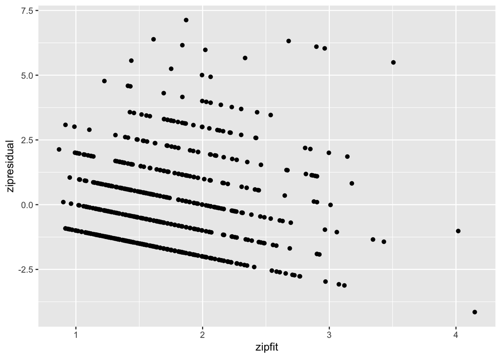

```r
data$zipfit <-zf1$fitted.values
data$zipresidual <- zf1$residuals

ggplot(data=data, aes(x=zipfit, y = zipresidual)) + geom_jitter(fill = "purple")
```